# Travel_Package_Purchase_Prediction

### Package-Level Analysis

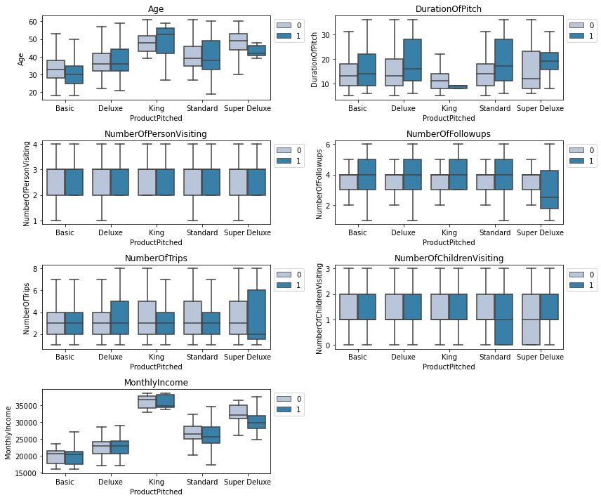

```python
cols = data[
    [
        'Age',
        'DurationOfPitch',
        'NumberOfPersonVisiting',
        'NumberOfFollowups',
        'NumberOfTrips',
        'NumberOfChildrenVisiting',
        'MonthlyIncome'
    ]
].columns.tolist()
plt.figure(figsize=(12, 10))

for i, variable in enumerate(cols):
    plt.subplot(4, 2, i + 1)
    sns.boxplot(
        data["ProductPitched"],
        data[variable],
        hue=data["ProdTaken"],
        palette="PuBu",
        showfliers=False,  # turning-off outliers
    )
    plt.tight_layout()
    plt.legend(loc="upper left", bbox_to_anchor=(1, 1))
    plt.title(variable)
plt.show()
```

- Super-Delux is the only product that significant affected customer decisions by Number of Follow-ups and Number of trips
- Number of Persons or Children visiting does not affect the customer preference for any product
- Duration of Pitch, Monthly Income and Age showed significant influence in determining the customer's package choice

### Summary of EDA

**Data Description:**

- There are 141 duplicate values in the dataset, which were dropped.
- There are missing values in the data.
- Most of the data-types are either **int64** or **float64**.

**Observations from EDA:**

- `Age:` It looks normally distributed
- `DurationOfPitch` It looks right skewed with extreme outliers.
  - After treating with the logarithmic scale, it has a more balanced distribution
- `NumberOfPersonVisiting` looks normally distributed
- `NumberOfFollowups` looks normally distributed
- `NumberOfTrips:` It looks right skewed with extreme outliers.
  - After treating with the logarithmic scale, it has a more balanced distribution
- `NumberOfChildrenVisiting:` It looks normally distributed
- `MonthlyIncome` looks normally distributed with many outliers.
  - The severity of the outliers was reduced on a logarithmic scale
- `TypeofContact` - Most of the contacts reached by the company was from Self Enquiry
- `Occupation` - An insignificant amount of Customers are Free Lancers
  - Most Customers earn salaries or have small businesses. This could explain why there are few high income earners compared to averge income earners
- `ProductPitched` - Most of the contacts reached by the company were presented with the Basic and Deluxe Package
- `MaritalStatus` - Most of the contacts reached by the company are married
- `Designation` - Most of the contacts reached by the company were executives and Managers
- `CityTier` - Most of the contacts reached by the company were from Tier 1.
  - The company is more interested in customers with higher living standards
- `PreferredPropertyStar` - Most of the customers prefer hotels with Rating 3
- `PitchSatisfactionScore` - Most of the sales pitch satisfaction score was average
- `Gender` - Most of the customers pitched to were Male

### Data Preprocessing

This will feature missing value Treatment, outlier detection if needed, feature Engineering and data preparation for modelling.

### Missing Value Treatment

```python
# let's check again for missing values
data.isnull().sum()
```

```
ProdTaken                     0
Age                         216
TypeofContact                25
CityTier                      0
DurationOfPitch             246
Occupation                    0
Gender                        0
NumberOfPersonVisiting        0
NumberOfFollowups            44
ProductPitched                0
PreferredPropertyStar        26
MaritalStatus                 0
NumberOfTrips               138
Passport                      0
PitchSatisfactionScore        0
OwnCar                        0
NumberOfChildrenVisiting     60
Designation                   0
MonthlyIncome               224
DurationOfPitch_log         246
NumberOfTrips_log           138
MonthlyIncome_log           224
dtype: int64
```

#### `NumberOfChildrenVisiting`

**Let's look at a few rows where number of children visiting is missing.**

```python
data[data["NumberOfChildrenVisiting"].isnull()][['NumberOfPersonVisiting', 'NumberOfChildrenVisiting']]
```

|  | NumberOfPersonVisiting | NumberOfChildrenVisiting |
| --- | --- | --- |
| 165 | 2 | NaN |
| 190 | 3 | NaN |
| 568 | 3 | NaN |
| 746 | 2 | NaN |
| 749 | 2 | NaN |
| 851 | 3 | NaN |
| 898 | 3 | NaN |
| 918 | 2 | NaN |
| 956 | 2 | NaN |
| 1009 | 3 | NaN |
| 1154 | 3 | NaN |
| 1242 | 2 | NaN |
| 1331 | 3 | NaN |
| 1401 | 3 | NaN |
| 1635 | 2 | NaN |
| 1660 | 3 | NaN |
| 2038 | 3 | NaN |
| 2219 | 2 | NaN |
| 2321 | 3 | NaN |
| 2368 | 3 | NaN |
| 2388 | 3 | NaN |
| 2426 | 3 | NaN |
| 2638 | 4 | NaN |
| 2679 | 4 | NaN |
| 2707 | 4 | NaN |
| 2744 | 3 | NaN |
| 2792 | 3 | NaN |
| 2823 | 4 | NaN |
| 2852 | 2 | NaN |
| 2889 | 3 | NaN |
| 2899 | 4 | NaN |
| 2910 | 4 | NaN |
| 2933 | 3 | NaN |
| 3005 | 3 | NaN |
| 3036 | 3 | NaN |
| 3060 | 4 | NaN |
| 3218 | 3 | NaN |
| 3349 | 3 | NaN |
| 3389 | 3 | NaN |
| 3443 | 3 | NaN |
| 3458 | 4 | NaN |
| 3487 | 3 | NaN |
| 3520 | 3 | NaN |
| 3522 | 3 | NaN |
| 3524 | 3 | NaN |
| 3540 | 3 | NaN |
| 3620 | 4 | NaN |
| 3638 | 3 | NaN |
| 3669 | 3 | NaN |
| 3792 | 4 | NaN |
| 4108 | 4 | NaN |
| 4149 | 4 | NaN |
| 4322 | 2 | NaN |
| 4359 | 3 | NaN |
| 4369 | 4 | NaN |
| 4380 | 4 | NaN |
| 4475 | 3 | NaN |
| 4506 | 3 | NaN |
| 4530 | 4 | NaN |
| 4819 | 3 | NaN |

**We'll impute these missing values one-by-one by taking the modal number of children for the number of persons visiting**

```python
# imputing missing values in Number of Children Visiting
data["NumberOfChildrenVisiting"] = data.groupby(["NumberOfPersonVisiting"])["NumberOfChildrenVisiting"].transform(
    lambda x: x.fillna(x.mode().iloc[0])
)
```

```python
# Checking missing values in Number of Children Visiting
data["NumberOfChildrenVisiting"].isnull().sum()
```

```
0
```

- All missing number of children has been taken care of

#### `Age and Number of Trips`

- It is expected that they should be affected by Gender, Marital Status and Designation

```python
cols_list = ["NumberOfTrips", "Age"]

for col in cols_list:
    data[col] = data.groupby(["Gender", "MaritalStatus", "Designation"])[col].transform(
        lambda x: x.fillna(x.median())
    )

data.isnull().sum()
```

```
ProdTaken                     0
Age                           0
TypeofContact                25
CityTier                      0
DurationOfPitch             246
Occupation                    0
Gender                        0
NumberOfPersonVisiting        0
NumberOfFollowups            44
ProductPitched                0
PreferredPropertyStar        26
MaritalStatus                 0
NumberOfTrips                 0
Passport                      0
PitchSatisfactionScore        0
OwnCar                        0
NumberOfChildrenVisiting      0
Designation                   0
MonthlyIncome               224
DurationOfPitch_log         246
NumberOfTrips_log           138
MonthlyIncome_log           224
dtype: int64
```

- All missing values in Age and Number of Trips have been treated

#### `DurationOfPitch, NumberOfFollowups, PreferredPropertyStar, and MonthlyIncome`

- It is expected that they should be affected by Occupation, Product Pitched, City Tier, and Designation

```python
cols_list = ["DurationOfPitch", "NumberOfFollowups", "PreferredPropertyStar", "MonthlyIncome"]

for col in cols_list:
    data[col] = data.groupby(["Occupation", "ProductPitched", "CityTier", "Designation"])[col].transform(
        lambda x: x.fillna(x.median())
    )

data.isnull().sum()
```

```
ProdTaken                     0
Age                           0
TypeofContact                25
CityTier                      0
DurationOfPitch               0
Occupation                    0
Gender                        0
NumberOfPersonVisiting        0
NumberOfFollowups             0
ProductPitched                0
PreferredPropertyStar         0
MaritalStatus                 0
NumberOfTrips                 0
Passport                      0
PitchSatisfactionScore        0
OwnCar                        0
NumberOfChildrenVisiting      0
Designation                   0
MonthlyIncome                 0
DurationOfPitch_log         246
NumberOfTrips_log           138
MonthlyIncome_log           224
dtype: int64
```

- All selected missing values have been treated

#### `TypeofContact`

```python
data["TypeofContact"] = data["TypeofContact"].fillna(data["TypeofContact"].mode().iloc[0])

data.isnull().sum()
```

```
ProdTaken                     0
Age                           0
TypeofContact                 0
CityTier                      0
DurationOfPitch               0
Occupation                    0
Gender                        0
NumberOfPersonVisiting        0
NumberOfFollowups             0
ProductPitched                0
PreferredPropertyStar         0
MaritalStatus                 0
NumberOfTrips                 0
Passport                      0
PitchSatisfactionScore        0
OwnCar                        0
NumberOfChildrenVisiting      0
Designation                   0
MonthlyIncome                 0
DurationOfPitch_log         246
NumberOfTrips_log           138
MonthlyIncome_log           224
dtype: int64
```

- All missing values have been treated

### Update of the Logarithm Fields

```python
data['NumberOfTrips_log'] = np.log(data.NumberOfTrips + 1)
data['DurationOfPitch_log'] = np.log(data.DurationOfPitch + 1)
data['MonthlyIncome_log'] = np.log(data.MonthlyIncome + 1)

data.isnull().sum()
```

```
ProdTaken                   0
Age                         0
TypeofContact               0
CityTier                    0
DurationOfPitch             0
Occupation                  0
Gender                      0
NumberOfPersonVisiting      0
NumberOfFollowups           0
ProductPitched              0
PreferredPropertyStar       0
MaritalStatus               0
NumberOfTrips               0
Passport                    0
PitchSatisfactionScore      0
OwnCar                      0
NumberOfChildrenVisiting    0
Designation                 0
MonthlyIncome               0
DurationOfPitch_log         0
NumberOfTrips_log           0
MonthlyIncome_log           0
dtype: int64
```

### Data Preparation

```python
data.info()
```

```
<class 'pandas.core.frame.DataFrame'>
Int64Index: 4747 entries, 0 to 4887
Data columns (total 22 columns):
 #   Column                    Non-Null Count  Dtype
---  ------                    --------------  -----
 0   ProdTaken                 4747 non-null   int64
 1   Age                       4747 non-null   float64
 2   TypeofContact             4747 non-null   category
 3   CityTier                  4747 non-null   int64
 4   DurationOfPitch           4747 non-null   float64
 5   Occupation                4747 non-null   category
 6   Gender                    4747 non-null   object
 7   NumberOfPersonVisiting    4747 non-null   int64
 8   NumberOfFollowups         4747 non-null   float64
 9   ProductPitched            4747 non-null   category
 10  PreferredPropertyStar     4747 non-null   float64
 11  MaritalStatus             4747 non-null   category
 12  NumberOfTrips             4747 non-null   float64
 13  Passport                  4747 non-null   int64
 14  PitchSatisfactionScore    4747 non-null   int64
 15  OwnCar                    4747 non-null   int64
 16  NumberOfChildrenVisiting  4747 non-null   float64
 17  Designation               4747 non-null   category
 18  MonthlyIncome             4747 non-null   float64
 19  DurationOfPitch_log       4747 non-null   float64
 20  NumberOfTrips_log         4747 non-null   float64
 21  MonthlyIncome_log         4747 non-null   float64
dtypes: category(5), float64(10), int64(6), object(1)
memory usage: 820.7+ KB
```

```python
# dropping PageValues
data = data.drop(["DurationOfPitch", "NumberOfTrips", "MonthlyIncome"], axis=1)
```

```python
# creating dummy varibles
dummy_data = pd.get_dummies(
    data,
    columns=[
        "TypeofContact",
        "Occupation",
        "ProductPitched",
        "MaritalStatus",
        "Gender",
        "Designation"

    ],
    drop_first=True,
)
dummy_data.head()
```

|  | ProdTaken | Age | CityTier | NumberOfPersonVisiting | NumberOfFollowups | PreferredPropertyStar | Passport | PitchSatisfactionScore | OwnCar | NumberOfChildrenVisiting | DurationOfPitch_log | NumberOfTrips_log | MonthlyIncome_log | TypeofContact_Self Enquiry | Occupation_Large Business | Occupation_Salaried | Occupation_Small Business | ProductPitched_Deluxe | ProductPitched_King | ProductPitched_Standard | ProductPitched_Super Deluxe | MaritalStatus_Married | MaritalStatus_Single | MaritalStatus_Unmarried | Gender_Male | Designation_Executive | Designation_Manager | Designation_Senior Manager | Designation_VP |
| --- | --- | --- | --- | --- | --- | --- | --- | --- | --- | --- | --- | --- | --- | --- | --- | --- | --- | --- | --- | --- | --- | --- | --- | --- | --- | --- | --- | --- | --- |
| 0 | 1 | 41.0 | 3 | 3 | 3.0 | 3.0 | 1 | 2 | 1 | 0.0 | 1.945910 | 0.693147 | 9.951992 | 1 | 0 | 1 | 0 | 1 | 0 | 0 | 0 | 0 | 1 | 0 | 0 | 0 | 1 | 0 | 0 |
| 1 | 0 | 49.0 | 1 | 3 | 4.0 | 4.0 | 0 | 3 | 1 | 2.0 | 2.708050 | 1.098612 | 9.910016 | 0 | 0 | 1 | 0 | 1 | 0 | 0 | 0 | 0 | 0 | 0 | 1 | 0 | 1 | 0 | 0 |
| 2 | 1 | 37.0 | 1 | 3 | 4.0 | 3.0 | 1 | 3 | 0 | 0.0 | 2.197225 | 2.079442 | 9.746307 | 1 | 0 | 0 | 0 | 0 | 0 | 0 | 0 | 0 | 1 | 0 | 1 | 1 | 0 | 0 | 0 |
| 3 | 0 | 33.0 | 1 | 2 | 3.0 | 3.0 | 1 | 5 | 1 | 1.0 | 2.302585 | 1.098612 | 9.793114 | 0 | 0 | 1 | 0 | 0 | 0 | 0 | 0 | 0 | 0 | 0 | 0 | 1 | 0 | 0 | 0 |
| 4 | 0 | 32.0 | 1 | 2 | 3.0 | 4.0 | 0 | 5 | 1 | 0.0 | 2.197225 | 0.693147 | 9.823849 | 1 | 0 | 0 | 1 | 0 | 0 | 0 | 0 | 0 | 0 | 0 | 1 | 1 | 0 | 0 | 0 |

## Split Data

```python
X = dummy_data.drop("ProdTaken", axis=1)  # Features
y = dummy_data["ProdTaken"] # Labels (Target Variable)
# converting target to integers - since some functions might not work with bool type
```

```python
# Splitting data into training and test set:
X_train, X_test, y_train, y_test = train_test_split(X, y, test_size=0.3, random_state=1, stratify=y)
print(X_train.shape, X_test.shape)
```

```
(3322, 28) (1425, 28)
```

```python
print("Number of rows in train data =", X_train.shape[0])
print("Number of rows in test data =", X_test.shape[0])
```

```
Number of rows in train data = 3322
Number of rows in test data = 1425
```

```python
print("Percentage of classes in training set:")
print(y_train.value_counts(normalize=True))
print("Percentage of classes in test set:")
print(y_test.value_counts(normalize=True))
```

```
Percentage of classes in training set:
0    0.811559
1    0.188441
Name: ProdTaken, dtype: float64
Percentage of classes in test set:
0    0.81193
1    0.18807
Name: ProdTaken, dtype: float64
```

## Model evaluation criterion

### Model can make wrong predictions as:

1. Predicting a customer will purchase a package and did not
2. Predicting a customer will not purchase a package and did

### How to reduce this loss i.e need to reduce False Negatives?

- Company wants Recall to be maximized, greater the Recall higher the chances of minimizing false negatives. Hence, the focus should be on increasing Recall or minimizing the false negatives or in other words identifying the true positives(i.e. Class 1) so that the company can provide incentives to control attrition rate especially for top-performers thereby optimizing the overall marketing cost.

**Let's define function to provide metric scores(accuracy,recall and precision) on train and test set and a function to show confusion matrix so that we do not have use the same code repetitively while evaluating models.**

```python
# defining a function to compute different metrics to check performance of a classification model built using sklearn
def model_performance_classification_sklearn(model, predictors, target):
    """
    Function to compute different metrics to check classification model performance

    model: classifier
    predictors: independent variables
    target: dependent variable
    """

    # predicting using the independent variables
    pred = model.predict(predictors)

    acc = accuracy_score(target, pred)  # to compute Accuracy
    recall = recall_score(target, pred)  # to compute Recall
    precision = precision_score(target, pred)  # to compute Precision
    f1 = f1_score(target, pred)  # to compute F1-score

    # creating a dataframe of metrics
    df_perf = pd.DataFrame(
        {
            "Accuracy": acc,
            "Recall": recall,
            "Precision": precision,
            "F1": f1,
        },
        index=[0],
    )

    return df_perf
```

```python
def confusion_matrix_sklearn(model, predictors, target):
    """
    To plot the confusion_matrix with percentages

    model: classifier
    predictors: independent variables
    target: dependent variable
    """
    y_pred = model.predict(predictors)
    cm = confusion_matrix(target, y_pred)
    labels = np.asarray(
        [
            ["{0:0.0f}".format(item) + "\n{0:.2%}".format(item / cm.flatten().sum())]
            for item in cm.flatten()
        ]
    ).reshape(2, 2)

    plt.figure(figsize=(6, 4))
    sns.heatmap(cm, annot=labels, fmt="")
    plt.ylabel("True label")
    plt.xlabel("Predicted label")
```

## Build Decision Tree Model

```python
dtree = DecisionTreeClassifier(criterion='gini',class_weight={0:0.81,1:0.19},random_state=1)
```

```python
dtree.fit(X_train, y_train)
```

```
DecisionTreeClassifier(class_weight={0: 0.81, 1: 0.19}, random_state=1)
```

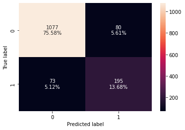

```python
confusion_matrix_sklearn(dtree, X_test, y_test)
```

**Confusion Matrix -**

- Product was Purchased and the model predicted it correctly that the product will be purchased : True Positive (observed=1,predicted=1)
- Product wasn't Purchased and the model predicted that the product will be purchased : False Positive (observed=0,predicted=1)
- Product wasn't Purchased and the model predicted that the product won't be purchased : True Negative (observed=0,predicted=0)
- Product was Purchased and the model predicted that the product won't be purchased : False Negative (observed=1,predicted=0)

```python
dtree_model_train_perf=model_performance_classification_sklearn(dtree, X_train, y_train)
print("Training performance \n",dtree_model_train_perf)
```

```
Training performance
    Accuracy  Recall  Precision   F1
0       1.0     1.0        1.0  1.0
```

```python
dtree_model_test_perf=model_performance_classification_sklearn(dtree, X_test, y_test)
print("Testing performance \n",dtree_model_test_perf)
```

```
Testing performance
    Accuracy    Recall  Precision        F1
0  0.892632  0.727612   0.709091  0.718232
```

- Decision tree is working well on the training data but is not able to generalize well on the test data concerning the recall.

### Bagging Classifier

```python
bagging = BaggingClassifier(random_state=1)
bagging.fit(X_train,y_train)
```

```
BaggingClassifier(random_state=1)
```

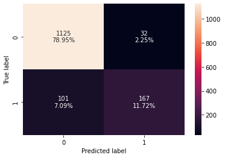

```python
confusion_matrix_sklearn(bagging, X_test, y_test)
```

```python
bagging_model_train_perf=model_performance_classification_sklearn(bagging, X_train, y_train)
print("Training performance \n",bagging_model_train_perf)
```

```
Training performance
    Accuracy    Recall  Precision        F1
0  0.994582  0.971246        1.0  0.985413
```

```python
bagging_model_test_perf=model_performance_classification_sklearn(bagging, X_test, y_test)
print("Testing performance \n",bagging_model_test_perf)
```

```
Testing performance
    Accuracy    Recall  Precision        F1
0  0.906667  0.623134   0.839196  0.715203
```

- Bagging classifier is overfitting on the training set and is performing poorly on the test set in terms of recall.

**Bagging Classifier with weighted decision tree**

```python
bagging_wt = BaggingClassifier(base_estimator=DecisionTreeClassifier(criterion='gini',class_weight={0:0.81,1:0.19},random_state=1),random_state=1)
bagging_wt.fit(X_train,y_train)
```

```
BaggingClassifier(base_estimator=DecisionTreeClassifier(class_weight={0: 0.81,
                                                                      1: 0.19},
                                                        random_state=1),
                  random_state=1)
```

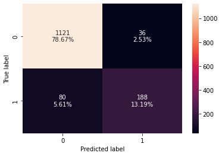

```python
confusion_matrix_sklearn(bagging_wt,X_test,y_test)
```

```python
bagging_wt_model_train_perf=model_performance_classification_sklearn(bagging_wt,X_train,y_train)
print("Training performance \n",bagging_wt_model_train_perf)
```

```
Training performance
    Accuracy    Recall  Precision        F1
0   0.99398  0.968051        1.0  0.983766
```

```python
bagging_wt_model_test_perf=model_performance_classification_sklearn(bagging_wt, X_test, y_test)
print("Testing performance \n",bagging_wt_model_test_perf)
```

```
Testing performance
    Accuracy    Recall  Precision        F1
0  0.918596  0.701493   0.839286  0.764228
```

- Bagging classifier with a weighted decision tree is giving very good accuracy and prediction but is not able to generalize well on test data in terms of recall.

### Random Forest

```python
rf = RandomForestClassifier(random_state=1)
rf.fit(X_train,y_train)
```

```
RandomForestClassifier(random_state=1)
```

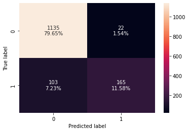

```python
confusion_matrix_sklearn(rf,X_test,y_test)
```

```python
rf_model_train_perf=model_performance_classification_sklearn(rf,X_train,y_train)
print("Training performance \n",rf_model_train_perf)
```

```
Training performance
    Accuracy  Recall  Precision   F1
0       1.0     1.0        1.0  1.0
```

```python
rf_model_test_perf=model_performance_classification_sklearn(rf,X_test,y_test)
print("Testing performance \n",rf_model_test_perf)
```

```
Testing performance
    Accuracy    Recall  Precision        F1
0  0.912281  0.615672   0.882353  0.725275
```

- Random Forest has performed well in terms of accuracy and precision, but it is not able to generalize well on the test data in terms of recall.

**Random forest with class weights**

```python
rf_wt = RandomForestClassifier(class_weight={0:0.81,1:0.19}, random_state=1)
rf_wt.fit(X_train,y_train)
```

```
RandomForestClassifier(class_weight={0: 0.81, 1: 0.19}, random_state=1)
```

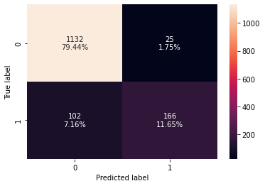

```python
confusion_matrix_sklearn(rf_wt, X_test,y_test)
```

```python
rf_wt_model_train_perf=model_performance_classification_sklearn(rf_wt, X_train,y_train)
print("Training performance \n",rf_wt_model_train_perf)
```

```
Training performance
    Accuracy  Recall  Precision   F1
0       1.0     1.0        1.0  1.0
```

```python
rf_wt_model_test_perf=model_performance_classification_sklearn(rf_wt, X_test,y_test)
print("Testing performance \n",rf_wt_model_test_perf)
```

```
Testing performance
    Accuracy    Recall  Precision        F1
0  0.910877  0.619403    0.86911  0.723312
```

- There is not much improvement in metrics of weighted random forest as compared to the unweighted random forest.

### Using GridSearch for Hyperparameter tuning model

- Hyperparameter tuning is also tricky in the sense that there is no direct way to calculate how a change in the hyperparameter value will reduce the loss of your model, so we usually resort to experimentation. i.e we'll use Grid search
- Grid search is a tuning technique that attempts to compute the optimum values of hyperparameters.
- It is an exhaustive search that is performed on a the specific parameter values of a model.
- The parameters of the estimator/model used to apply these methods are optimized by cross-validated grid-search over a parameter grid.

**Tuning Decision Tree**

```python
# Choose the type of classifier.
dtree_estimator = DecisionTreeClassifier(class_weight={0:0.81,1:0.19},random_state=1)

# Grid of parameters to choose from
parameters = {'max_depth': np.arange(2,30),
              'min_samples_leaf': [1, 2, 5, 7, 10],
              'max_leaf_nodes' : [2, 3, 5, 10,15],
              'min_impurity_decrease': [0.0001,0.001,0.01,0.1]
             }

# Type of scoring used to compare parameter combinations
scorer = metrics.make_scorer(metrics.recall_score)

# Run the grid search
grid_obj = GridSearchCV(dtree_estimator, parameters, scoring=scorer)
grid_obj = grid_obj.fit(X_train, y_train)

# Set the clf to the best combination of parameters
dtree_estimator = grid_obj.best_estimator_

# Fit the best algorithm to the data.
dtree_estimator.fit(X_train, y_train)
```

```
DecisionTreeClassifier(class_weight={0: 0.81, 1: 0.19}, max_depth=5,
                       max_leaf_nodes=15, min_impurity_decrease=0.0001,
                       min_samples_leaf=5, random_state=1)
```

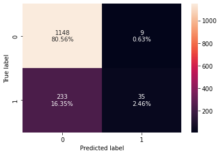

```python
confusion_matrix_sklearn(dtree_estimator, X_test,y_test)
```

```python
dtree_estimator_model_train_perf=model_performance_classification_sklearn(dtree_estimator, X_train,y_train)
print("Training performance \n",dtree_estimator_model_train_perf)
```

```
Training performance
    Accuracy    Recall  Precision        F1
0  0.838049  0.146965   0.958333  0.254848
```

```python
dtree_estimator_model_test_perf=model_performance_classification_sklearn(dtree_estimator, X_test, y_test)
print("Testing performance \n",dtree_estimator_model_test_perf)
```

```
Testing performance
    Accuracy    Recall  Precision        F1
0  0.830175  0.130597   0.795455  0.224359
```

- Overfitting in decision tree has reduced but the recall has also reduced.

**Tuning Bagging Classifier**

```python
# grid search for bagging classifier
cl1 = DecisionTreeClassifier(class_weight={0:0.81,1:0.19},random_state=1)
param_grid = {'base_estimator':[cl1],
              'n_estimators':[5,7,15,51,101],
              'max_features': [0.7,0.8,0.9,1]
             }

grid = GridSearchCV(BaggingClassifier(random_state=1,bootstrap=True), param_grid=param_grid, scoring = 'recall', cv = 5)
grid.fit(X_train, y_train)
```

```
GridSearchCV(cv=5, estimator=BaggingClassifier(random_state=1),
             param_grid={'base_estimator': [DecisionTreeClassifier(class_weight={0: 0.81,
                                                                                 1: 0.19},
                                                                   random_state=1)],
                         'max_features': [0.7, 0.8, 0.9, 1],
                         'n_estimators': [5, 7, 15, 51, 101]},
             scoring='recall')
```

```python
## getting the best estimator
bagging_estimator  = grid.best_estimator_
bagging_estimator.fit(X_train,y_train)
```

```
BaggingClassifier(base_estimator=DecisionTreeClassifier(class_weight={0: 0.81,
                                                                      1: 0.19},
                                                        random_state=1),
                  max_features=0.9, n_estimators=101, random_state=1)
```

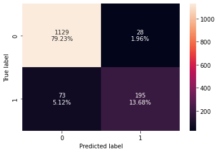

```python
confusion_matrix_sklearn(bagging_estimator, X_test,y_test)
```

```python
bagging_estimator_model_train_perf=model_performance_classification_sklearn(bagging_estimator, X_train,y_train)
print("Training performance \n",bagging_estimator_model_train_perf)
```

```
Training performance
    Accuracy  Recall  Precision   F1
0       1.0     1.0        1.0  1.0
```

```python
bagging_estimator_model_test_perf=model_performance_classification_sklearn(bagging_estimator, X_test, y_test)
print("Testing performance \n",bagging_estimator_model_test_perf)
```

```
Testing performance
    Accuracy    Recall  Precision        F1
0  0.929123  0.727612   0.874439  0.794297
```

**Tuning Random Forest**

```python
# Choose the type of classifier.
rf_estimator = RandomForestClassifier(class_weight={0:0.81,1:0.19}, random_state=1)

# Grid of parameters to choose from
parameters = {
        "n_estimators": [51, 110,251,501],
        "min_samples_leaf": np.arange(1, 6,1),
        "max_features": [0.7, 0.8, 0.9,'log2','auto'],
        "max_samples": [0.7, 0.8, 0.9,None],
}

# Run the grid search
grid_obj = GridSearchCV(rf_estimator, parameters, scoring='recall', verbose=1, n_jobs=-1, cv=5)
grid_obj = grid_obj.fit(X_train, y_train)

# Set the clf to the best combination of parameters
rf_estimator = grid_obj.best_estimator_

# Fit the best algorithm to the data.
rf_estimator.fit(X_train, y_train)
```

```
Fitting 5 folds for each of 400 candidates, totalling 2000 fits
```

```
RandomForestClassifier(class_weight={0: 0.81, 1: 0.19}, max_features=0.8,
                       n_estimators=501, random_state=1)
```

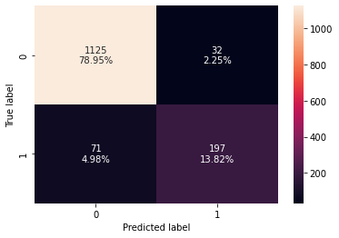

```python
confusion_matrix_sklearn(rf_estimator, X_test,y_test)
```

```python
rf_estimator_model_train_perf=model_performance_classification_sklearn(rf_estimator, X_train,y_train)
print("Training performance \n",rf_estimator_model_train_perf)
```

```
Training performance
    Accuracy  Recall  Precision   F1
0       1.0     1.0        1.0  1.0
```

```python
rf_estimator_model_test_perf=model_performance_classification_sklearn(rf_estimator, X_test, y_test)
print("Testing performance \n",rf_estimator_model_test_perf)
```

```
Testing performance
    Accuracy    Recall  Precision        F1
0  0.927719  0.735075   0.860262  0.792757
```

- Random forest after tuning has given better performance than un-tuned random forest.

### Comparing all the baggging models

```python
# training performance comparison

models_train_comp_df = pd.concat(
    [dtree_model_train_perf.T,bagging_model_train_perf.T, bagging_wt_model_train_perf.T,rf_model_train_perf.T,
    rf_wt_model_train_perf.T,dtree_estimator_model_train_perf.T, bagging_estimator_model_train_perf.T,
     rf_estimator_model_train_perf.T],
    axis=1,
)
models_train_comp_df.columns = [
    "Decision Tree",
    "Bagging Classifier",
    "Weighted Bagging Classifier",
    "Random Forest Classifier",
    "Weighted Random Forest Classifier",
    "Decision Tree Estimator",
    "Bagging Estimator",
    "Random Forest Estimator"]
print("Training performance comparison:")
models_train_comp_df
```

```
Training performance comparison:
```

|  | Decision Tree | Bagging Classifier | Weighted Bagging Classifier | Random Forest Classifier | Weighted Random Forest Classifier | Decision Tree Estimator | Bagging Estimator | Random Forest Estimator |
| --- | --- | --- | --- | --- | --- | --- | --- | --- |
| Accuracy | 1.0 | 0.994582 | 0.993980 | 1.0 | 1.0 | 0.838049 | 1.0 | 1.0 |
| Recall | 1.0 | 0.971246 | 0.968051 | 1.0 | 1.0 | 0.146965 | 1.0 | 1.0 |
| Precision | 1.0 | 1.000000 | 1.000000 | 1.0 | 1.0 | 0.958333 | 1.0 | 1.0 |
| F1 | 1.0 | 0.985413 | 0.983766 | 1.0 | 1.0 | 0.254848 | 1.0 | 1.0 |

```python
# training performance comparison

models_test_comp_df = pd.concat(
    [dtree_model_test_perf.T,bagging_model_test_perf.T, bagging_wt_model_test_perf.T,rf_model_test_perf.T,
    rf_wt_model_test_perf.T,dtree_estimator_model_test_perf.T, bagging_estimator_model_test_perf.T,
     rf_estimator_model_test_perf.T],
    axis=1,
)
models_test_comp_df.columns = [
    "Decision Tree",
    "Bagging Classifier",
    "Weighted Bagging Classifier",
    "Random Forest Classifier",
    "Weighted Random Forest Classifier",
    "Decision Tree Estimator",
    "Bagging Estimator",
    "Random Forest Estimator"]
print("Testing performance comparison:")
models_test_comp_df
```

```
Testing performance comparison:
```

|  | Decision Tree | Bagging Classifier | Weighted Bagging Classifier | Random Forest Classifier | Weighted Random Forest Classifier | Decision Tree Estimator | Bagging Estimator | Random Forest Estimator |
| --- | --- | --- | --- | --- | --- | --- | --- | --- |
| Accuracy | 0.892632 | 0.906667 | 0.918596 | 0.912281 | 0.910877 | 0.830175 | 0.929123 | 0.927719 |
| Recall | 0.727612 | 0.623134 | 0.701493 | 0.615672 | 0.619403 | 0.130597 | 0.727612 | 0.735075 |
| Precision | 0.709091 | 0.839196 | 0.839286 | 0.882353 | 0.869110 | 0.795455 | 0.874439 | 0.860262 |
| F1 | 0.718232 | 0.715203 | 0.764228 | 0.725275 | 0.723312 | 0.224359 | 0.794297 | 0.792757 |

## Boosting Models

### AdaBoost Classifier

```python
ab_Classifier=AdaBoostClassifier(random_state=1)
ab_Classifier.fit(X_train,y_train)
```

```
AdaBoostClassifier(random_state=1)
```

```python
ab_Classifier_model_train_perf = model_performance_classification_sklearn(ab_Classifier, X_train,y_train)
print("Training performance \n",ab_Classifier_model_train_perf)
```

```
Training performance
    Accuracy   Recall  Precision        F1
0  0.851896  0.36262   0.709375  0.479915
```

```python
ab_Classifier_model_test_perf = model_performance_classification_sklearn(ab_Classifier, X_test,y_test)
print("Testing performance \n",ab_Classifier_model_test_perf)
```

```
Testing performance
    Accuracy    Recall  Precision        F1
0  0.842105  0.313433      0.672  0.427481
```

### Hyperparameter Tuning

```python
# Choose the type of classifier.
ab_tuned = AdaBoostClassifier(random_state=1)

# Grid of parameters to choose from
parameters = {'n_estimators': np.arange(10,100,10),
              'learning_rate': [1, 0.1, 0.5, 0.01],
              }

# Type of scoring used to compare parameter combinations
scorer = metrics.make_scorer(metrics.recall_score)

# Run the grid search
grid_obj = GridSearchCV(ab_tuned, parameters, scoring=scorer, verbose=1, n_jobs=-1, cv=5)
grid_obj = grid_obj.fit(X_train, y_train)

# Set the clf to the best combination of parameters
ab_tuned = grid_obj.best_estimator_

# Fit the best algorithm to the data.
ab_tuned.fit(X_train, y_train)
```

```
Fitting 5 folds for each of 36 candidates, totalling 180 fits
```

```
AdaBoostClassifier(learning_rate=1, n_estimators=80, random_state=1)
```

```python
ab_tuned_model_train_perf = model_performance_classification_sklearn(ab_tuned, X_train,y_train)
print("Training performance \n",ab_tuned_model_train_perf)
```

```
Training performance
    Accuracy    Recall  Precision        F1
0  0.854907  0.365815   0.729299  0.487234
```

```python
ab_tuned_model_test_perf = model_performance_classification_sklearn(ab_tuned, X_test,y_test)
print("Testing performance \n",ab_tuned_model_train_perf)
```

```
Testing performance
    Accuracy    Recall  Precision        F1
0  0.854907  0.365815   0.729299  0.487234
```

- We can see that there is no significant improvement in the model after hyperparameter tuning.

### Gradient Boosting Classifier

```python
gb_estimator=GradientBoostingClassifier(random_state=1)
gb_estimator.fit(X_train,y_train)
```

```
GradientBoostingClassifier(random_state=1)
```

```python
gb_estimator_model_train_perf = model_performance_classification_sklearn(gb_estimator, X_train,y_train)
print("Training performance \n",gb_estimator_model_train_perf)
```

```
Training performance
    Accuracy    Recall  Precision        F1
0  0.892836  0.498403   0.881356  0.636735
```

```python
gb_estimator_model_test_perf = model_performance_classification_sklearn(gb_estimator, X_test, y_test)
print("Testing performance \n",gb_estimator_model_test_perf)
```

```
Testing performance
    Accuracy    Recall  Precision        F1
0  0.861053  0.406716   0.736486  0.524038
```

- Gradient boosting is generalizing well and giving decent results but not as good as random forest.

### Hyperparameter Tuning

```python
# Choose the type of classifier.
gb_tuned = GradientBoostingClassifier(random_state=1)

# Grid of parameters to choose from
parameters = {'n_estimators': np.arange(50,200,25),
              'subsample':[0.7,0.8,0.9,1],
              'max_features':[0.7,0.8,0.9,1],
              'max_depth':[3,5,7,10]
              }

# Type of scoring used to compare parameter combinations
scorer = metrics.make_scorer(metrics.recall_score)

# Run the grid search
grid_obj = GridSearchCV(gb_tuned, parameters, scoring=scorer, verbose=1, n_jobs=-1, cv=5)
grid_obj = grid_obj.fit(X_train, y_train)

# Set the clf to the best combination of parameters
gb_tuned = grid_obj.best_estimator_

# Fit the best algorithm to the data.
gb_tuned.fit(X_train, y_train)
```

```
Fitting 5 folds for each of 384 candidates, totalling 1920 fits
```

```
GradientBoostingClassifier(max_depth=10, max_features=0.8, n_estimators=150,
                           random_state=1, subsample=1)
```

```python
gb_tuned_model_train_perf = model_performance_classification_sklearn(gb_tuned, X_train,y_train)
print("Training performance \n",gb_tuned_model_train_perf)
```

```
Training performance
    Accuracy  Recall  Precision   F1
0       1.0     1.0        1.0  1.0
```

```python
gb_tuned_model_test_perf = model_performance_classification_sklearn(gb_tuned, X_test, y_test)
print("Testing performance \n",gb_tuned_model_test_perf)
```

```
Testing performance
    Accuracy    Recall  Precision        F1
0  0.941754  0.764925   0.911111  0.831643
```

- There was a highly significant improvement with the tuned Model

```python
# importance of features in the tree building ( The importance of a feature is computed as the
#(normalized) total reduction of the criterion brought by that feature. It is also known as the Gini importance )

print(pd.DataFrame(gb_tuned.feature_importances_, columns = ["Imp"], index = X_train.columns).sort_values(by = 'Imp', ascending = False))
```

```
                                  Imp
MonthlyIncome_log            0.144657
DurationOfPitch_log          0.132876
Age                          0.132189
Passport                     0.071862
Designation_Executive        0.062500
NumberOfTrips_log            0.057544
PitchSatisfactionScore       0.056487
NumberOfFollowups            0.053968
CityTier                     0.048991
PreferredPropertyStar        0.030775
MaritalStatus_Single         0.025551
MaritalStatus_Unmarried      0.020233
Gender_Male                  0.016560
MaritalStatus_Married        0.016071
NumberOfPersonVisiting       0.015552
Occupation_Large Business    0.015371
TypeofContact_Self Enquiry   0.014749
Occupation_Salaried          0.013083
Occupation_Small Business    0.012784
NumberOfChildrenVisiting     0.011786
Designation_Manager          0.011298
OwnCar                       0.008577
ProductPitched_Deluxe        0.007605
ProductPitched_Standard      0.006761
ProductPitched_Super Deluxe  0.004626
Designation_Senior Manager   0.004422
ProductPitched_King          0.001995
Designation_VP               0.001127
```

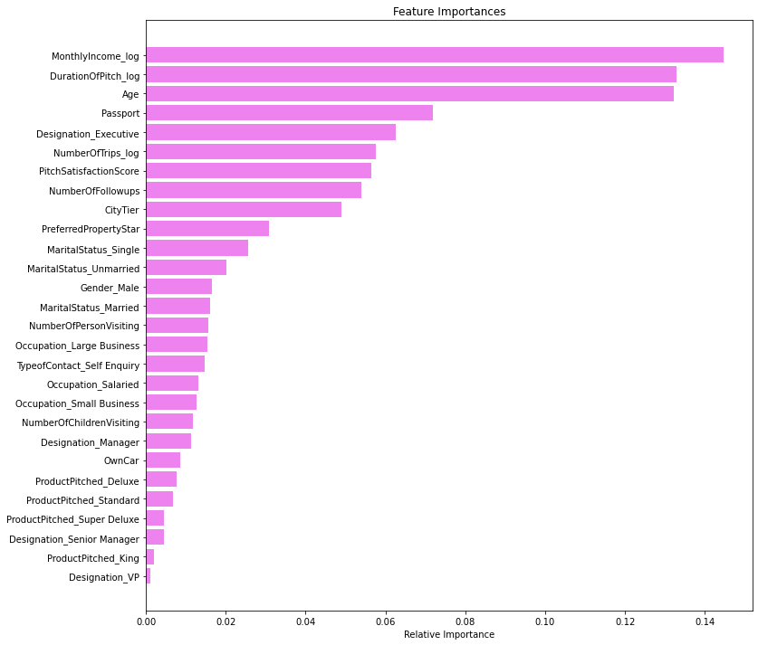

```python
feature_names = X_train.columns
importances = gb_tuned.feature_importances_
indices = np.argsort(importances)

plt.figure(figsize=(12,12))
plt.title('Feature Importances')
plt.barh(range(len(indices)), importances[indices], color='violet', align='center')
plt.yticks(range(len(indices)), [feature_names[i] for i in indices])
plt.xlabel('Relative Importance')
plt.show()
```

### XGBoost Classifier

```python
xgb_estimator=XGBClassifier(random_state=1,eval_metric='logloss')
xgb_estimator.fit(X_train,y_train)
```

```
XGBClassifier(base_score=0.5, booster='gbtree', colsample_bylevel=1,
              colsample_bynode=1, colsample_bytree=1, enable_categorical=False,
              eval_metric='logloss', gamma=0, gpu_id=-1, importance_type=None,
              interaction_constraints='', learning_rate=0.300000012,
              max_delta_step=0, max_depth=6, min_child_weight=1, missing=nan,
              monotone_constraints='()', n_estimators=100, n_jobs=4,
              num_parallel_tree=1, predictor='auto', random_state=1,
              reg_alpha=0, reg_lambda=1, scale_pos_weight=1, subsample=1,
              tree_method='exact', validate_parameters=1, verbosity=None)
```

```python
xgb_estimator_model_train_perf = model_performance_classification_sklearn(xgb_estimator, X_train, y_train)
print("Training performance \n",xgb_estimator_model_train_perf)
```

```
Training performance
    Accuracy  Recall  Precision   F1
0       1.0     1.0        1.0  1.0
```

```python
xgb_estimator_model_test_perf = model_performance_classification_sklearn(xgb_estimator, X_test,y_test)
print("Testing performance \n",xgb_estimator_model_test_perf)
```

```
Testing performance
    Accuracy    Recall  Precision        F1
0  0.917895  0.679104    0.85446  0.756757
```

### Comparing all the boosting models

```python
# training performance comparison

models_train_comp_df = pd.concat(
    [ab_Classifier_model_train_perf.T,ab_tuned_model_train_perf.T, gb_estimator_model_train_perf.T,
    gb_tuned_model_train_perf.T,xgb_estimator_model_train_perf.T],
    axis=1,
)
models_train_comp_df.columns = [
    "AdaBoost Classifier",
    "AdaBoost Estimator",
    "Gradient Boosting Classifier",
    "Gradient Boosting Estimator",
    "XGBoost Classifier"]
print("Training performance comparison:")
models_train_comp_df
```

```
Training performance comparison:
```

|  | AdaBoost Classifier | AdaBoost Estimator | Gradient Boosting Classifier | Gradient Boosting Estimator | XGBoost Classifier |
| --- | --- | --- | --- | --- | --- |
| Accuracy | 0.851896 | 0.854907 | 0.892836 | 1.0 | 1.0 |
| Recall | 0.362620 | 0.365815 | 0.498403 | 1.0 | 1.0 |
| Precision | 0.709375 | 0.729299 | 0.881356 | 1.0 | 1.0 |
| F1 | 0.479915 | 0.487234 | 0.636735 | 1.0 | 1.0 |

```python
# Test performance comparison

models_train_comp_df = pd.concat(
    [ab_Classifier_model_test_perf.T,ab_tuned_model_test_perf.T, gb_estimator_model_test_perf.T,
    gb_tuned_model_test_perf.T,xgb_estimator_model_test_perf.T],
    axis=1,
)
models_train_comp_df.columns = [
    "AdaBoost Classifier",
    "AdaBoost Estimator",
    "Gradient Boosting Classifier",
    "Gradient Boosting Estimator",
    "XGBoost Classifier"]
print("Test performance comparison:")
models_train_comp_df
```

```
Test performance comparison:
```

|  | AdaBoost Classifier | AdaBoost Estimator | Gradient Boosting Classifier | Gradient Boosting Estimator | XGBoost Classifier |
| --- | --- | --- | --- | --- | --- |
| Accuracy | 0.842105 | 0.840000 | 0.861053 | 0.941754 | 0.917895 |
| Recall | 0.313433 | 0.298507 | 0.406716 | 0.764925 | 0.679104 |
| Precision | 0.672000 | 0.666667 | 0.736486 | 0.911111 | 0.854460 |
| F1 | 0.427481 | 0.412371 | 0.524038 | 0.831643 | 0.756757 |

## Stacking Model

```python
estimators=[('Bagging', bagging_estimator),('Random Forest', gb_tuned),
           ('Gradient Boosting', gb_tuned)]
final_estimator=XGBClassifier(random_state=1,eval_metric='logloss')
```

```python
stacking_estimator=StackingClassifier(estimators=estimators, final_estimator=final_estimator,cv=5)
stacking_estimator.fit(X_train,y_train)
```

```
StackingClassifier(cv=5,
                   estimators=[('Bagging',
                                BaggingClassifier(base_estimator=DecisionTreeClassifier(class_weight={0: 0.81,
                                                                                                      1: 0.19},
                                                                                        random_state=1),
                                                  max_features=0.9,
                                                  n_estimators=101,
                                                  random_state=1)),
                               ('Random Forest',
                                GradientBoostingClassifier(max_depth=10,
                                                           max_features=0.8,
                                                           n_estimators=150,
                                                           random_state=1,
                                                           subsample=1)),
                               ('Gradient Boosting',
                                GradientBoos...
                                                 interaction_constraints=None,
                                                 learning_rate=None,
                                                 max_delta_step=None,
                                                 max_depth=None,
                                                 min_child_weight=None,
                                                 missing=nan,
                                                 monotone_constraints=None,
                                                 n_estimators=100, n_jobs=None,
                                                 num_parallel_tree=None,
                                                 predictor=None, random_state=1,
                                                 reg_alpha=None,
                                                 reg_lambda=None,
                                                 scale_pos_weight=None,
                                                 subsample=None,
                                                 tree_method=None,
                                                 validate_parameters=None,
                                                 verbosity=None))
```

```python
stacking_estimator_model_train_perf = model_performance_classification_sklearn(stacking_estimator, X_train, y_train)
print("Training performance \n",stacking_estimator_model_train_perf)
```

```
Training performance
    Accuracy    Recall  Precision        F1
0  0.999097  0.998403    0.99681  0.997606
```

```python
stacking_estimator_model_test_perf = model_performance_classification_sklearn(stacking_estimator, X_test, y_test)
print("Testing performance \n",stacking_estimator_model_test_perf)
```

```
Testing performance
    Accuracy    Recall  Precision        F1
0  0.917895  0.720149   0.821277  0.767396
```

## Comparing all models

```python
# training performance comparison

models_train_comp_df = pd.concat(
    [dtree_model_train_perf.T,
     bagging_model_train_perf.T,
     bagging_wt_model_train_perf.T,
     rf_model_train_perf.T,
     rf_wt_model_train_perf.T,
     dtree_estimator_model_train_perf.T,
     bagging_estimator_model_train_perf.T,
     rf_estimator_model_train_perf.T,
     ab_Classifier_model_train_perf.T,
     ab_tuned_model_train_perf.T,
     gb_estimator_model_train_perf.T,
     gb_tuned_model_train_perf.T
     ,xgb_estimator_model_train_perf.T,
     stacking_estimator_model_train_perf.T],
    axis=1,
)

models_train_comp_df.columns = [
    "Decision Tree",
    "Bagging Classifier",
    "Weighted Bagging Classifier",
    "Random Forest Classifier",
    "Weighted Random Forest Classifier",
    "Decision Tree Estimator",
    "Bagging Estimator",
    "Random Forest Estimator",
    "AdaBoost Classifier",
    "AdaBoost Estimator",
    "Gradient Boosting Classifier",
    "Gradient Boosting Estimator",
    "XGBoost Classifier",
    "Stacking Classifier"
]

print("Training performance comparison:")
models_train_comp_df.T
```

```
Training performance comparison:
```

|  | Accuracy | Recall | Precision | F1 |
| --- | --- | --- | --- | --- |
| Decision Tree | 1.000000 | 1.000000 | 1.000000 | 1.000000 |
| Bagging Classifier | 0.994582 | 0.971246 | 1.000000 | 0.985413 |
| Weighted Bagging Classifier | 0.993980 | 0.968051 | 1.000000 | 0.983766 |
| Random Forest Classifier | 1.000000 | 1.000000 | 1.000000 | 1.000000 |
| Weighted Random Forest Classifier | 1.000000 | 1.000000 | 1.000000 | 1.000000 |
| Decision Tree Estimator | 0.838049 | 0.146965 | 0.958333 | 0.254848 |
| Bagging Estimator | 1.000000 | 1.000000 | 1.000000 | 1.000000 |
| Random Forest Estimator | 1.000000 | 1.000000 | 1.000000 | 1.000000 |
| AdaBoost Classifier | 0.851896 | 0.362620 | 0.709375 | 0.479915 |
| AdaBoost Estimator | 0.854907 | 0.365815 | 0.729299 | 0.487234 |
| Gradient Boosting Classifier | 0.892836 | 0.498403 | 0.881356 | 0.636735 |
| Gradient Boosting Estimator | 1.000000 | 1.000000 | 1.000000 | 1.000000 |
| XGBoost Classifier | 1.000000 | 1.000000 | 1.000000 | 1.000000 |
| Stacking Classifier | 0.999097 | 0.998403 | 0.996810 | 0.997606 |

```python
# test performance comparison

models_test_comp_df = pd.concat(
    [dtree_model_test_perf.T,
     bagging_model_test_perf.T,
     bagging_wt_model_test_perf.T,
     rf_model_test_perf.T,
     rf_wt_model_test_perf.T,
     dtree_estimator_model_test_perf.T,
     bagging_estimator_model_test_perf.T,
     rf_estimator_model_test_perf.T,
     ab_Classifier_model_test_perf.T,
     ab_tuned_model_test_perf.T,
     gb_estimator_model_test_perf.T,
     gb_tuned_model_test_perf.T
     ,xgb_estimator_model_test_perf.T,
     stacking_estimator_model_test_perf.T],
    axis=1,
)

models_test_comp_df.columns = [
    "Decision Tree",
    "Bagging Classifier",
    "Weighted Bagging Classifier",
    "Random Forest Classifier",
    "Weighted Random Forest Classifier",
    "Decision Tree Estimator",
    "Bagging Estimator",
    "Random Forest Estimator",
    "AdaBoost Classifier",
    "AdaBoost Estimator",
    "Gradient Boosting Classifier",
    "Gradient Boosting Estimator",
    "XGBoost Classifier",
    "Stacking Classifier"
]

print("Test performance comparison:")
models_test_comp_df.T
```

```
Test performance comparison:
```

|  | Accuracy | Recall | Precision | F1 |
| --- | --- | --- | --- | --- |
| Decision Tree | 0.892632 | 0.727612 | 0.709091 | 0.718232 |
| Bagging Classifier | 0.906667 | 0.623134 | 0.839196 | 0.715203 |
| Weighted Bagging Classifier | 0.918596 | 0.701493 | 0.839286 | 0.764228 |
| Random Forest Classifier | 0.912281 | 0.615672 | 0.882353 | 0.725275 |
| Weighted Random Forest Classifier | 0.910877 | 0.619403 | 0.869110 | 0.723312 |
| Decision Tree Estimator | 0.830175 | 0.130597 | 0.795455 | 0.224359 |
| Bagging Estimator | 0.929123 | 0.727612 | 0.874439 | 0.794297 |
| Random Forest Estimator | 0.927719 | 0.735075 | 0.860262 | 0.792757 |
| AdaBoost Classifier | 0.842105 | 0.313433 | 0.672000 | 0.427481 |
| AdaBoost Estimator | 0.840000 | 0.298507 | 0.666667 | 0.412371 |
| Gradient Boosting Classifier | 0.861053 | 0.406716 | 0.736486 | 0.524038 |
| Gradient Boosting Estimator | 0.941754 | 0.764925 | 0.911111 | 0.831643 |
| XGBoost Classifier | 0.917895 | 0.679104 | 0.854460 | 0.756757 |
| Stacking Classifier | 0.917895 | 0.720149 | 0.821277 | 0.767396 |

- The tuned gradient boosting model is the best model here.
- Gradient boosting, Random Forest, and Bagging Estimator are the top 3 models. They are all giving a similar performance.

## Business Recommendations

- The company should focus on indexes that indicate affluence in a customer. This includes a high monthly income, executive designation or large businesses
- More attention should be given to the customers who have obtained a passport
- After a pitch, there should be improved follow up
- The company should not pursue customers when there is a low pitch satisfaction score
- The company should pay more attention to well travelled customers
- The marketing should be focused on the younger population customers who are more likely to prefer theor products